# Tarea 7

Estudio a BBVA

Gibrán Leonardo Chávez González

2026-09-20

# Tarea 7

## Estimación, simulación y validación del movimiento browniano geométrico

**Unidad 2**

**Propósito.** Esta actividad busca integrar datos reales, estimación de parámetros, simulación Monte Carlo y cálculo teórico bajo movimiento browniano geométrico (GBM). Deberás comparar la aproximación local basada en $dS_t$ con la solución exacta del GBM, evaluar la normalidad de distintas transformaciones y discutir cuándo cada aproximación es adecuada.

### Indicaciones

Entrega un documento HTML generado desde RMarkdown que incluya:

- código reproducible;
- resultados numéricos;
- gráficas;
- respuestas interpretativas;
- procedimientos teóricos claramente desarrollados.

Para las probabilidades empíricas utiliza al menos $100{,}000$ simulaciones.

Usa 252 días bursátiles por año, salvo que se indique lo contrario.

**Importante.** En esta tarea compararemos dos aproximaciones distintas:

$$\Delta S \approx \mu S_0 T + \sigma S_0
\sqrt{T}\, Z, \qquad Z \sim N(0,1),$$

que es una **aproximación local**, y

$$S_T = S_0 \exp\left[ \left( \mu -
\tfrac{1}{2}\sigma^2 \right) T + \sigma \sqrt{T}\, Z
\right],$$

que es la **solución exacta** del GBM.

## Problema 1. Datos reales y estimación de parámetros

Selecciona un activo financiero que cotice diariamente y pueda descargarse desde Yahoo Finance. Puedes utilizar, por ejemplo, una emisora de la BMV.

Descarga al menos dos años de datos diarios y trabaja con precios ajustados.

```r
library(quantmod); library(moments); library(tseries); set.seed(666)
```

```r
ticker <- 'BBVA'
fecha_inicio <- '2020-01-01'
fecha_fin <- '2026-09-21'
```

```r
getSymbols(
  ticker,
  src = 'yahoo',
  from = fecha_inicio,
  to = fecha_fin
)
```

```
## [1] "BBVA"
```

```r
precio <- na.omit(Ad(get(ticker)))
log_precio <- log(precio)

head(
  cbind(
    precio,
    log_precio
  )
)
```

```
##            BBVA.Adjusted BBVA.Adjusted.1
## 2020-01-02      3.905148        1.362296
## 2020-01-03      3.809568        1.337516
## 2020-01-06      3.836876        1.344659
## 2020-01-07      3.782259        1.330321
## 2020-01-08      3.823222        1.341094
## 2020-01-09      3.830049        1.342878
```

**a)** Grafica la serie de precios y la serie de log-precios.

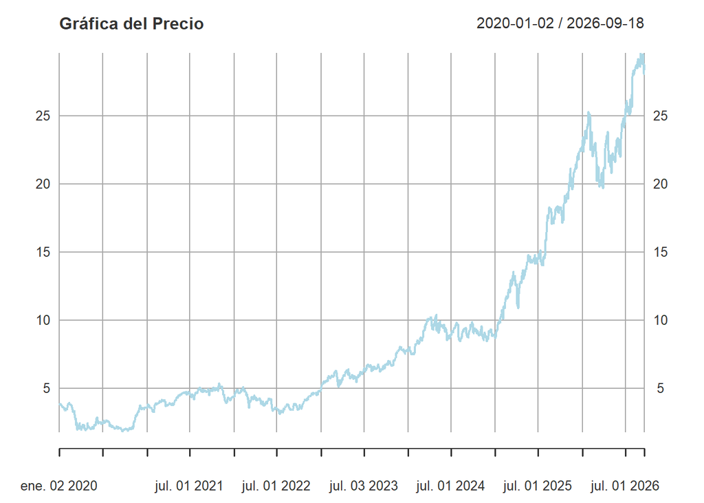

```r
plot(
  precio,
  main = 'Gráfica del Precio',
  col = 'lightblue'
)
```

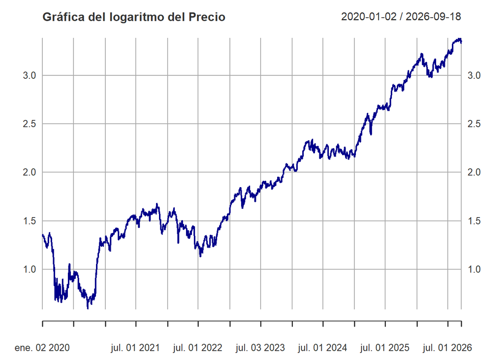

```r
plot(
  log_precio,
  main = 'Gráfica del logaritmo del Precio',
  col = 'darkblue'
)
```

**b)** Calcula los rendimientos simples:

$$R_t = \frac{S_t -
S_{t-1}}{S_{t-1}},$$

y los log-rendimientos:

$$r_t = \ln\left( \frac{S_t}{S_{t-1}}
\right).$$

```r
simple_rets <- na.omit(dailyReturn(
  precio,
  type = 'arithmetic',
  leading = FALSE
))

log_rets <- na.omit(dailyReturn(
  precio,
  type = 'log',
  leading = FALSE
))

head(
  cbind(
    simple_rets,
    log_rets
  )
)
```

```
##            daily.returns daily.returns.1
## 2020-01-03  -0.024475472    -0.024779975
## 2020-01-06   0.007168389     0.007142818
## 2020-01-07  -0.014234800    -0.014337087
## 2020-01-08   0.010830346     0.010772118
## 2020-01-09   0.001785635     0.001784042
## 2020-01-10  -0.021390230    -0.021622317
```

**c)** Estima:

$$\bar{r}_{\text{daily}} \quad \text{y}
\quad \hat{\sigma}_{\text{daily}}.$$

```r
r_daily_s <- mean(simple_rets); sigma_daily_s <- sd(simple_rets)

r_daily_l <- mean(log_rets); sigma_daily_l <- sd(log_rets)

r_daily_s; sigma_daily_s
```

```
## [1] 0.001486784
```

```
## [1] 0.024821
```

```r
r_daily_l; sigma_daily_l
```

```
## [1] 0.001175969
```

```
## [1] 0.02496339
```

**d)** Anualiza la volatilidad:

$$\hat{\sigma}_{\text{ann}} =
\hat{\sigma}_{\text{daily}} \sqrt{252}.$$

```r
sigma_anual_s <- sigma_daily_s * sqrt(252)
sigma_anual_l <- sigma_daily_l * sqrt(252)

sigma_anual_s; sigma_anual_l
```

```
## [1] 0.3940211
```

```
## [1] 0.3962815
```

**e)** Bajo GBM, utiliza

$$E[r_{\Delta t}] = \left( \mu -
\tfrac{1}{2}\sigma^2 \right) \Delta t$$

para estimar

$$\hat{\mu} = 252\, \bar{r}_{\text{daily}}
+ \tfrac{1}{2} \hat{\sigma}^2_{\text{ann}}.$$

```r
mu_s <- 252 * r_daily_s
mu_l <- 252 * r_daily_l + 0.5 * sigma_anual_l^2

mu_s; mu_l
```

```
## [1] 0.3746697
```

```
## [1] 0.3748637
```

**f)** Explica por qué

$$252\,
\bar{r}_{\text{daily}}$$

no debe interpretarse directamente como $\hat{\mu}$.

El parámetro $\mu$ del GBM es el drift de la **variación relativa del precio**, $\frac{dS_t}{S_t} = \mu\,dt + \sigma\,dW_t$, no el drift del log-precio. Al aplicar el lema de Itô a $f(S) = \ln S$, el término de segundo orden no desaparece, porque $(dW_t)^2 = dt$, y se obtiene

$$d\ln S_t = \left(\mu -
\tfrac{1}{2}\sigma^2\right)dt + \sigma\,dW_t .$$

Por lo tanto, la media de los log-rendimientos diarios estima $(\mu - \tfrac12\sigma^2)\Delta t$, y al multiplicarla por 252 obtenemos una estimación de $\mu - \tfrac12\sigma^2$, no de $\mu$. La corrección $-\tfrac12\sigma^2$ no es un supuesto adicional: la genera la variación cuadrática del movimiento browniano.

Las dos cantidades tienen interpretaciones distintas:

- $\mu - \tfrac12\sigma^2$ es el crecimiento del log-precio y determina la **mediana**: $\text{Mediana}(S_T) = S_0 e^{(\mu-\sigma^2/2)T}$.
- $\mu$ determina la **media**: $E[S_T] = S_0 e^{\mu T}$.

**g)** Reporta en una tabla:

$$S_0,\quad \bar{r}_{\text{daily}},\quad
\hat{\sigma}_{\text{daily}},\quad \hat{\sigma}_{\text{ann}},\quad
\hat{\mu}.$$

```r
knitr::kable(cbind(
  S0 = as.numeric(last(precio)),
  r_daily_l,
  sigma_daily_l,
  sigma_anual_l,
  mu_l
))
```

| S0 | r_daily_l | sigma_daily_l | sigma_anual_l | mu_l |
| --- | --- | --- | --- | --- |
| 28.36 | 0.001176 | 0.0249634 | 0.3962815 | 0.3748637 |

## Problema 2. Diagnóstico distribucional

Utiliza los datos reales del Problema 1.

**a)** Construye un histograma del precio $S_t$.

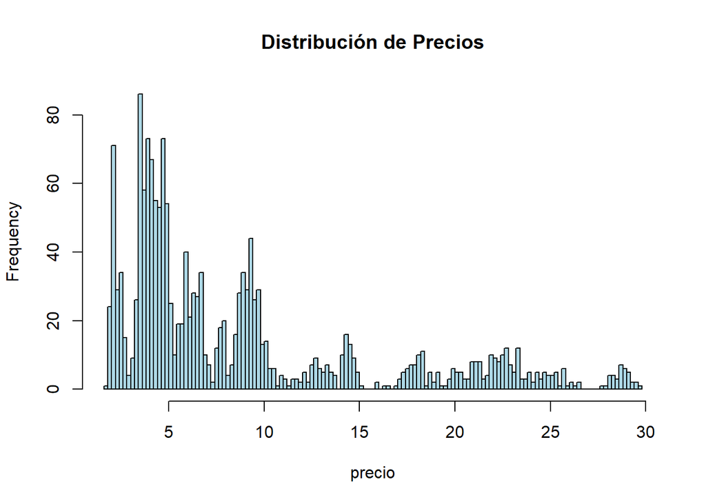

```r
hist(
  precio,
  main = 'Distribución de Precios',
  n = 100,
  col = 'lightblue'
)
```

**b)** Construye un histograma de $\ln S_t$.

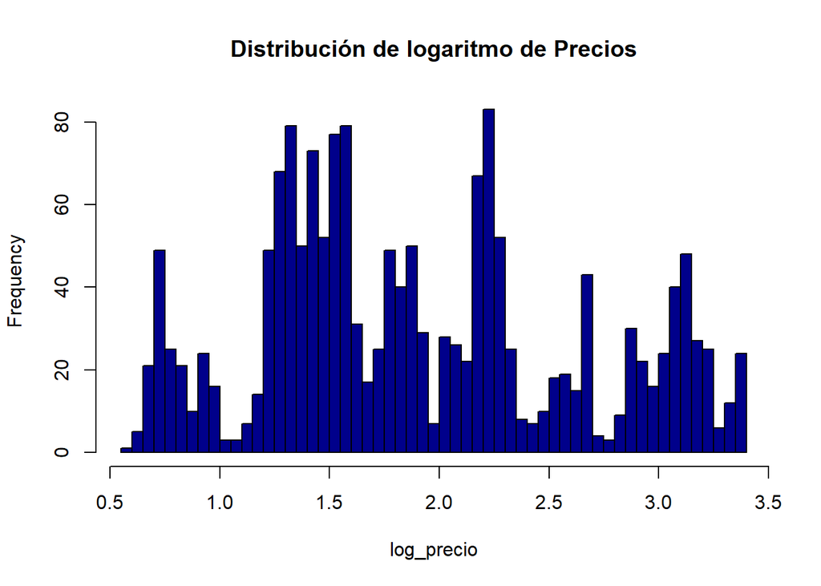

```r
hist(
  log_precio,
  main = 'Distribución de logaritmo de Precios',
  n = 100,
  col = 'darkblue'
)
```

**c)** Construye histogramas de $R_t$ y $r_t$.

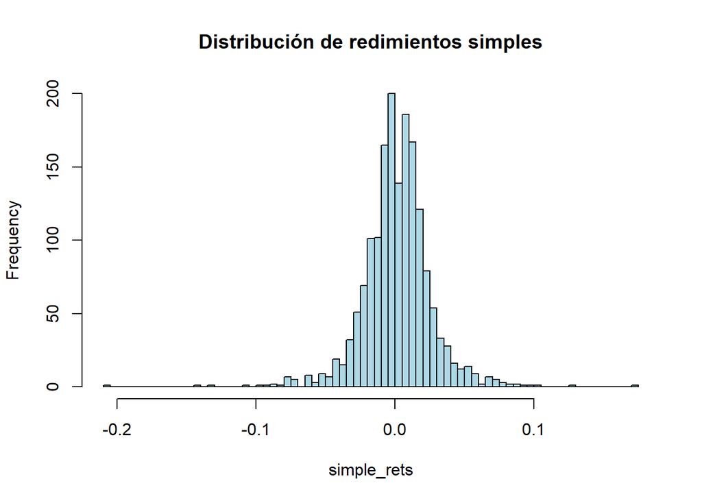

```r
hist(
  simple_rets,
  main = 'Distribución de redimientos simples',
  n = 100,
  col = 'lightblue'
)
```

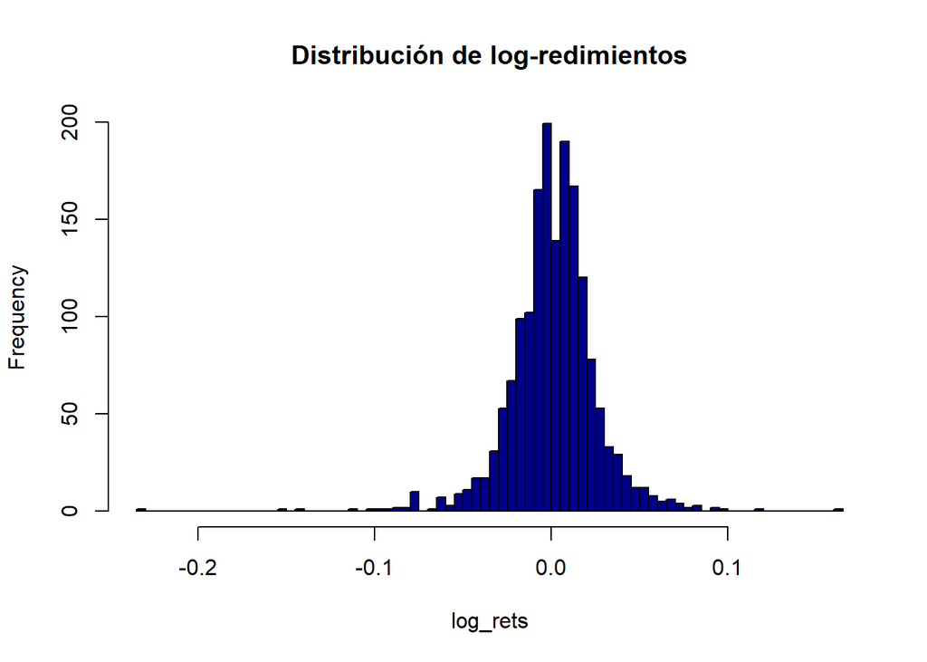

```r
hist(
  log_rets,
  main = 'Distribución de log-redimientos',
  n = 100,
  col = 'darkblue'
)
```

**d)** Para cada una de las cuatro variables anteriores, aplica una prueba de Jarque–Bera.

$$H_0: \text{Los datos son
normales}$$

$$H_1: \text{Los datos no son
normales}$$

```r
variables <- list(
  'Precio S_t' = precio,
  'log-Precio ln(S_t)' = log_precio,
  'Rend. Simples Rt' = simple_rets,
  'Log-Rend ln(Rt)' = log_rets
)

pruebas <- lapply(variables, function(x) jarque.bera.test(as.numeric(x)))
pruebas
```

```
## $`Precio S_t`
##
##  Jarque Bera Test
##
## data:  as.numeric(x)
## X-squared = 531.13, df = 2, p-value < 2.2e-16
##
##
## $`log-Precio ln(S_t)`
##
##  Jarque Bera Test
##
## data:  as.numeric(x)
## X-squared = 75.899, df = 2, p-value < 2.2e-16
##
##
## $`Rend. Simples Rt`
##
##  Jarque Bera Test
##
## data:  as.numeric(x)
## X-squared = 3599.3, df = 2, p-value < 2.2e-16
##
##
## $`Log-Rend ln(Rt)`
##
##  Jarque Bera Test
##
## data:  as.numeric(x)
## X-squared = 5309.6, df = 2, p-value < 2.2e-16
```

**e)** Resume los resultados en una tabla con:

- estadístico, p-value, decisión sobre $H_0$.

```r
tabla_jb <- data.frame(
  Variable    = names(pruebas),
  Estadistico = sapply(pruebas, function(p) unname(p$statistic)),
  p_value     = sapply(pruebas, function(p) p$p.value),
  row.names   = NULL
)

tabla_jb$Decision <- ifelse(tabla_jb$p_value < 0.05, "Se rechaza H0", "No se rechaza H0")
tabla_jb$p_value  <- format.pval(tabla_jb$p_value, digits = 3)

knitr::kable(tabla_jb)
```

| Variable | Estadistico | p_value | Decision |
| --- | --- | --- | --- |
| Precio S_t | 531.13266 | <2e-16 | Se rechaza H0 |
| log-Precio ln(S_t) | 75.89895 | <2e-16 | Se rechaza H0 |
| Rend. Simples Rt | 3599.28553 | <2e-16 | Se rechaza H0 |
| Log-Rend ln(Rt) | 5309.64281 | <2e-16 | Se rechaza H0 |

**f)** ¿Cuál de estas pruebas está más directamente relacionada con el supuesto distribucional del GBM? Justifica formalmente.

La prueba relevante es la de los **log-rendimientos** $r_t$.

Al integrar la ecuación de Itô para $\ln S_t$ entre $t-\Delta t$ y $t$:

$$r_t = \ln\frac{S_t}{S_{t-\Delta t}} =
\left(\mu - \tfrac12\sigma^2\right)\Delta t + \sigma\left(W_t -
W_{t-\Delta t}\right).$$

Los incrementos del proceso de Wiener sobre intervalos que no se traslapan son independientes y cumplen $W_t - W_{t-\Delta t} \sim N(0, \Delta t)$. Por lo tanto, bajo GBM:

$$r_t \overset{iid}{\sim}
N\!\left(\left(\mu - \tfrac12\sigma^2\right)\Delta t,\ \sigma^2\Delta
t\right).$$

Esa es la implicación distribucional del modelo que sí se puede contrastar con una muestra: los $r_t$ son observaciones independientes de una misma normal, justo lo que supone Jarque–Bera. Las otras variables no son normales según el modelo:

- $S_t$ es **lognormal** (positiva y sesgada a la derecha), no normal.
- $\ln S_t$ sí es normal para cada $t$ fijo, pero la serie histórica no es una muestra de una sola distribución (ver inciso g).

Se rechaza con fuerza la normalidad que el GBM implica: los datos de BBVA contradicen este supuesto del modelo.

**g)** Explica por qué probar normalidad sobre toda la serie histórica

$$\ln S_1,\ \ln S_2,\ \dots,\ \ln
S_n$$

debe interpretarse con cautela.

Jarque–Bera supone que los datos son observaciones **independientes de una misma distribución**. La serie de log-precios no cumple ninguna de las dos condiciones, ni siquiera si el GBM fuera cierto:

1. **No hay una distribución común.** Bajo GBM, $\ln S_t \sim N\!\left(\ln S_0 + (\mu - \tfrac12\sigma^2)t,\ \sigma^2 t\right)$: la media y la varianza cambian con $t$. Cada $\ln S_t$ proviene de una normal diferente, y mezclarlas no produce una normal.
2. **No son independientes.** $\ln S_t$ es una caminata aleatoria con drift: cada valor es el anterior más un incremento. Los log-precios consecutivos comparten casi toda su historia y están muy correlacionados.
3. **Es una sola trayectoria.** La trayectoria observada es una realización del proceso estocástico, no el proceso completo. El histograma de $\ln S_t$ refleja la forma de *ese* camino: con BBVA, la tendencia de 0.59 a 3.39 en log-precio. No refleja la distribución de $\ln S_T$ para un $T$ fijo, de la que solo tenemos una observación por fecha.

**h)** Conecta tus resultados con los hechos estilizados de la Parte A: heavy tails, asimetría y clustering de volatilidad.

```r
r_log <- as.numeric(log_rets)

hechos <- data.frame(
  Medida = c('Asimetría',
             'Curtosis (Normal = 3)',
             '% de días con |z| > 3 (datos)',
             '% de días con |z| > 3 (Normal)'),
  Valor = c(skewness(r_log),
            kurtosis(r_log),
            100 * mean(abs(scale(r_log)) > 3),
            100 * 2 * pnorm(-3))
)

knitr::kable(hechos, digits = 3)
```

| Medida | Valor |
| --- | --- |
| Asimetría | -0.704 |
| Curtosis (Normal = 3) | 11.579 |
| % de días con \|z\| > 3 (datos) | 1.839 |
| % de días con \|z\| > 3 (Normal) | 0.270 |

```r
vol_por_anio <- tapply(r_log, format(index(log_rets), '%Y'), sd) * sqrt(252)
knitr::kable(t(round(vol_por_anio, 3)), caption = 'Volatilidad anualizada por año')
```

Volatilidad anualizada por año

| 2020 | 2021 | 2022 | 2023 | 2024 | 2025 | 2026 |
| --- | --- | --- | --- | --- | --- | --- |
| 0.649 | 0.325 | 0.398 | 0.287 | 0.307 | 0.317 | 0.358 |

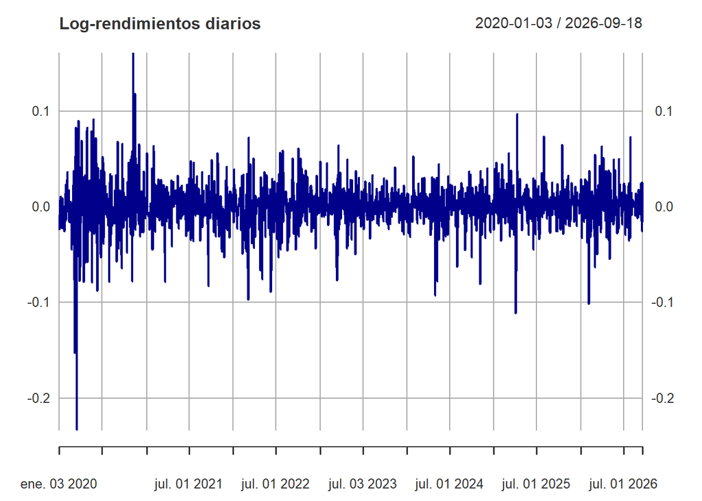

```r
plot(log_rets, main = 'Log-rendimientos diarios', col = 'darkblue')
```

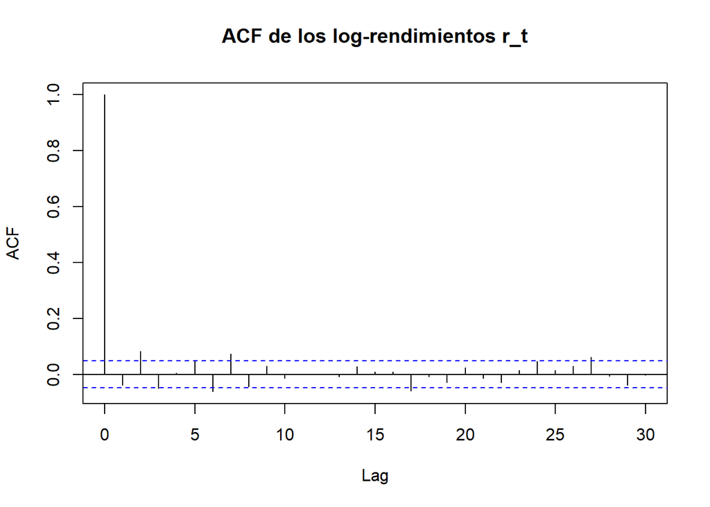

```r
acf_r  <- acf(r_log,   lag.max = 30, main = 'ACF de los log-rendimientos r_t')
```

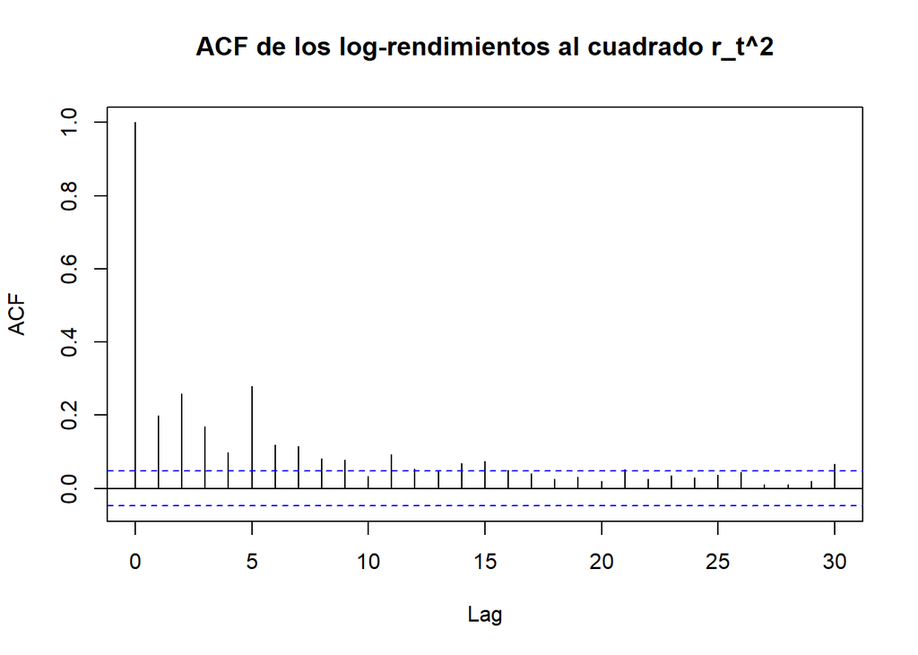

```r
acf_r2 <- acf(r_log^2, lag.max = 30, main = 'ACF de los log-rendimientos al cuadrado r_t^2')
```

```r
banda <- qnorm(0.975) / sqrt(length(r_log))   # bandas azules del 95 %

fuera_r  <- sum(abs(acf_r$acf[-1])  > banda)
fuera_r2 <- sum(abs(acf_r2$acf[-1]) > banda)
```

El rechazo de normalidad en los rendimientos no es una anomalía de BBVA: es la huella de los hechos estilizados que aparecen en casi todas las series financieras.

## Problema 3. Probabilidad teórica y empírica a corto plazo

Utiliza los parámetros estimados en el Problema 1 y el último precio observado como $S_0$.

Estima la probabilidad de que el precio del activo disminuya durante los próximos 5 días bursátiles.

```r
So <- as.numeric(last(precio)); T <- 5/252
```

**a)** Usando la aproximación local:

$$\Delta S \approx \mu S_0 T + \sigma S_0
\sqrt{T}\, Z,$$

calcula teóricamente

$$P(\Delta S < 0).$$

```r
delta_s <- 0

E_delta_s <- mu_l * So * T
Var_delta_s <- sigma_anual_l^2 * So^2 * T
SD_delta_s <- sqrt(Var_delta_s)

Zo <- (delta_s - E_delta_s) / SD_delta_s

p3_teo_aprox <- pnorm(
  Zo,
  mean = 0,
  sd = 1
)

p3_teo_aprox
```

```
## [1] 0.4469994
```

**b)** Estima empíricamente la misma probabilidad mediante al menos 100,000 simulaciones de $\Delta S$.

```r
Z <- rnorm(
  1000000,
  mean = 0,
  sd = 1
)

Delta_s <- mu_l * So * T + sigma_anual_l * So * sqrt(T) * Z

p3_emp_aprox <- mean(Delta_s < delta_s)

p3_emp_aprox
```

```
## [1] 0.447176
```

**c)** Usando la solución exacta:

$$S_T = S_0 e^{(\mu - \sigma^2/2)T +
\sigma \sqrt{T}\, Z},$$

calcula teóricamente

$$P(S_T < S_0).$$

```r
E_st <- log(So) + (mu_l - 0.5 * sigma_anual_l^2) * T
sd_st <- sigma_anual_l * sqrt(T)

Zo_ <- (log(So) - E_st) / sd_st

p3_teo_exacta <- pnorm(
  Zo_,
  mean = 0,
  sd = 1
)

p3_teo_exacta
```

```
## [1] 0.4580545
```

**d)** Estima empíricamente esa probabilidad mediante Monte Carlo.

```r
ST <- So * exp((mu_l - 0.5 * sigma_anual_l^2)*T + sigma_anual_l * sqrt(T) * Z)

p3_emp_exacta <- mean(ST < So)

p3_emp_exacta
```

```
## [1] 0.458226
```

**e)** Compara los cuatro resultados en una sola tabla.

```r
tabla_3 <- data.frame(
  Ecuación = c('Aprox. Local', 'Sol. Exacta'),
  Teórica = c(p3_teo_aprox, p3_teo_exacta),
  Empírica = c(p3_emp_aprox, p3_emp_exacta)
)

knitr::kable(tabla_3)
```

| Ecuación | Teórica | Empírica |
| --- | --- | --- |
| Aprox. Local | 0.4469994 | 0.447176 |
| Sol. Exacta | 0.4580545 | 0.458226 |

**f)** Explica por qué esperas que la aproximación local y la solución exacta sean relativamente cercanas a 5 días.

La aproximación local es un paso de Euler–Maruyama: sustituye $dt$ y $dW_t$ por incrementos finitos $T$ y $\sqrt{T}Z$, y deja fijo el precio en $S_0$ durante todo el intervalo. Es una buena aproximación cuando el intervalo es pequeño, por tres razones:

1. **La corrección de Itô es de orden** $T$. Las dos probabilidades solo difieren en el drift: la local usa $\mu$ y la exacta usa $\mu - \tfrac12\sigma^2$. Al estandarizar,

   $$z_{\text{local}} =
   -\frac{\mu\sqrt{T}}{\sigma}, \qquad z_{\text{exacta}} = -\frac{(\mu -
   \sigma^2/2)\sqrt{T}}{\sigma}, \qquad z_{\text{exacta}} -
   z_{\text{local}} = \frac{\sigma\sqrt{T}}{2}.$$

   A 5 días esa diferencia es de apenas 0.0279 desviaciones estándar, lo que mueve la probabilidad en aproximadamente $\phi(0)\cdot0.0279 \approx 0.0111$.
2. **Linealizar la exponencial casi no cambia nada.** La solución exacta es $S_T/S_0 = e^{X}$ con $X$ de orden $\sigma\sqrt{T} \approx 0.056$. Para $X$ pequeño, $e^X \approx 1 + X$, así que la lognormal casi no se distingue de una normal y el sesgo a la derecha es mínimo.
3. **Domina el choque aleatorio.** El componente esperado $\mu T \approx 0.0074$ es pequeño frente al aleatorio $\sigma\sqrt{T} \approx 0.0558$, porque el primero escala con $T$ y el segundo con $\sqrt{T}$. Ambas probabilidades quedan cerca de 0.5 y la manera de tratar el drift pesa poco.

Por eso a 5 días obtenemos 0.447 (local) contra 0.4581 (exacta): una diferencia de 0.0111, prácticamente la que predice la fórmula anterior.

## Problema 4. La misma probabilidad a un año

Repite el Problema 3 para

$$T = 1.$$

```r
So <- as.numeric(last(precio)); T <- 1
```

**a)** Calcula la probabilidad teórica usando la aproximación local.

```r
delta_s <- 0

E_delta_s <- mu_l * So * T
Var_delta_s <- sigma_anual_l^2 * So^2 * T
SD_delta_s <- sqrt(Var_delta_s)

Zo <- (delta_s - E_delta_s) / SD_delta_s

p4_teo_aprox <- pnorm(
  Zo,
  mean = 0,
  sd = 1
)

p4_teo_aprox
```

```
## [1] 0.1720862
```

**b)** Estima la probabilidad empírica usando la aproximación local.

```r
Z <- rnorm(
  1000000,
  mean = 0,
  sd = 1
)

Delta_s <- mu_l * So * T + sigma_anual_l * So * sqrt(T) * Z

p4_emp_aprox <- mean(Delta_s < delta_s)

p4_emp_aprox
```

```
## [1] 0.172098
```

**c)** Calcula la probabilidad teórica usando la solución exacta.

```r
E_st <- log(So) + (mu_l - 0.5 * sigma_anual_l^2) * T
sd_st <- sigma_anual_l * sqrt(T)

Zo_ <- (log(So) - E_st) / sd_st

p4_teo_exacta <- pnorm(
  Zo_,
  mean = 0,
  sd = 1
)

p4_teo_exacta
```

```
## [1] 0.2272866
```

**d)** Estima la probabilidad empírica usando la solución exacta.

```r
ST <- So * exp((mu_l - 0.5 * sigma_anual_l^2)*T + sigma_anual_l * sqrt(T) * Z)

p4_emp_exacta <- mean(ST < So)

p4_emp_exacta
```

```
## [1] 0.227276
```

**e)** Compara los resultados con los obtenidos a 5 días.

```r
knitr::kable(tabla_3) # 5 días
```

| Ecuación | Teórica | Empírica |
| --- | --- | --- |
| Aprox. Local | 0.4469994 | 0.447176 |
| Sol. Exacta | 0.4580545 | 0.458226 |

```r
tabla_4 <- data.frame(
  Ecuación = c('Aprox. Local', 'Sol. Exacta'),
  Teórica = c(p4_teo_aprox, p4_teo_exacta),
  Empírica = c(p4_emp_aprox, p4_emp_exacta)
)

knitr::kable(tabla_4) # 1 año
```

| Ecuación | Teórica | Empírica |
| --- | --- | --- |
| Aprox. Local | 0.1720862 | 0.172098 |
| Sol. Exacta | 0.2272866 | 0.227276 |

| Horizonte | Local | Exacta | Diferencia |
| --- | --- | --- | --- |
| 5 días | 0.447 | 0.4581 | 0.0111 |
| 1 año | 0.1721 | 0.2273 | 0.0552 |

- **Las dos probabilidades bajan con el horizonte.** El componente esperado crece linealmente con $T$ y el aleatorio con $\sqrt{T}$. La razón drift/volatilidad, $\mu\sqrt{T}/\sigma$, aumenta con el tiempo, así que con $\mu > 0$ es cada vez menos probable terminar por debajo de $S_0$.
- **La brecha entre métodos se multiplica.** Pasa de 0.0111 a 0.0552, unas 5 veces más. A un año, la aproximación local subestima la probabilidad de pérdida en 24.3 % de su valor exacto.
- **Monte Carlo coincide con la teoría en ambos horizontes.** La simulación reproduce cada fórmula, pero no corrige el error de la aproximación: simular la ecuación local solo reproduce la probabilidad local. La discrepancia viene del modelo aproximado, no del número de simulaciones.

**f)** ¿Qué método se deteriora más al aumentar el horizonte? Explica por qué.

Se deteriora la **aproximación local**. La solución exacta no pierde precisión con el horizonte: es la solución de la ecuación del GBM para cualquier $T$, y su único error posible es el del propio modelo. La aproximación local, en cambio, acumula tres errores que crecen con $T$:

1. **Omite la corrección de Itô.** Usa $\mu$ como drift cuando el log-precio crece a tasa $\mu - \tfrac12\sigma^2$. La distancia entre los valores $z$ es $\sigma\sqrt{T}/2$, que crece con la raíz del horizonte: 0.028 a 5 días y 0.198 a un año. Por eso la local ubica la mediana del precio demasiado arriba y subestima la probabilidad de caída.
2. **Supone normalidad del cambio en el precio.** $\Delta S$ normal es simétrica, pero bajo GBM $S_T$ es lognormal, con sesgo a la derecha, y la mediana queda por debajo de la media. Con horizontes largos esa asimetría es grande, y la normal además asigna probabilidad positiva a precios negativos.
3. **Congela el precio en** $S_0$. En el GBM tanto el drift como la volatilidad escalan con el precio *actual* $S_t$. La aproximación local los fija en $S_0$ e ignora la capitalización compuesta del camino, un efecto despreciable en 5 días pero no en un año.

En resumen, la aproximación local equivale a un solo paso de Euler–Maruyama de tamaño $T$. Es razonable para intervalos pequeños, pero no para horizontes largos.

## Problema 5. Precios futuros e intervalos de probabilidad

Utiliza nuevamente $S_0$, $\hat{\mu}$ y $\hat{\sigma}$ del activo real.

Para cada horizonte

$$T \in \left\{ \frac{1}{252},\
\frac{10}{252},\ \frac{60}{252},\ 1 \right\},$$

```r
Ts <- c(
  '1 día' = 1/252,
  '10 días' = 10/252,
  '60 días' = 60/252,
  '252 días / 1 año' = 1)
```

determina:

**a)**

$$E[S_T] = S_0 e^{\mu T}.$$

```r
E_ST <- So * exp(mu_l * Ts)
knitr::kable(E_ST, col.names = 'E[St]')
```

|  | E[St] |
| --- | --- |
| 1 día | 28.40222 |
| 10 días | 28.78502 |
| 60 días | 31.00762 |
| 252 días / 1 año | 41.25793 |

**b)**

$$Var(S_T) = S_0^2 e^{2\mu T} \left(
e^{\sigma^2 T} - 1 \right).$$

```r
Var_ST <- So^2 * exp(2 * mu_l * Ts) * (exp(sigma_anual_l^2 * Ts) - 1)
knitr::kable(Var_ST, col.names = 'Var[St]')
```

|  | Var[St] |
| --- | --- |
| 1 día | 0.5028597 |
| 10 días | 5.1795743 |
| 60 días | 36.6302238 |
| 252 días / 1 año | 289.4471147 |

**c)** La mediana:

$$\text{Median}(S_T) = S_0 e^{(\mu -
\sigma^2/2)T}.$$

```r
Mediana_ST <- So * exp((mu_l - 0.5 * sigma_anual_l^2) * Ts)
knitr::kable(Mediana_ST, col.names = 'Mediana[St]')
```

|  | Mediana[St] |
| --- | --- |
| 1 día | 28.39337 |
| 10 días | 28.69547 |
| 60 días | 30.43331 |
| 252 días / 1 año | 38.14230 |

**d)** Un intervalo central de probabilidad del 95 % para $S_T$.

```r
intervalo_confianza <- function(So, mu, sigma, T, nc){
  z_nc = qnorm(1 - (1 - nc) / 2)

  c(
    inferior = So * exp(((mu - 0.5 * sigma^2) * T) - z_nc * sigma * sqrt(T)),
    superior = So * exp(((mu - 0.5 * sigma^2) * T) + z_nc * sigma * sqrt(T))
  )
}
```

```r
IC_95 <- sapply(
  Ts,
  function(t) intervalo_confianza(So, mu_l, sigma_anual_l, t, 0.95)
  )
knitr::kable(IC_95)
```

|  | 1 día | 10 días | 60 días | 252 días / 1 año |
| --- | --- | --- | --- | --- |
| inferior | 27.03760 | 24.58208 | 20.83321 | 17.54250 |
| superior | 29.81713 | 33.49718 | 44.45722 | 82.93203 |

**e)** La probabilidad

$$P(S_T > 1.10\, S_0).$$

```r
E_log_ST  <- log(So) + (mu_l - 0.5 * sigma_anual_l^2) * Ts
sd_log_ST <- sigma_anual_l * sqrt(Ts)

P_sube_10 <- pnorm((log(1.1 * So) - E_log_ST) / sd_log_ST, lower.tail = FALSE)
knitr::kable(P_sube_10, col.names = 'P(St > 1.1St)')
```

|  | P(St > 1.1St) |
| --- | --- |
| 1 día | 0.0000813 |
| 10 días | 0.1449390 |
| 60 días | 0.4490720 |
| 252 días / 1 año | 0.6940282 |

**f)** Resume todos los resultados en una tabla y describe cómo cambia la incertidumbre al aumentar $T$.

```r
tabla_5 <- data.frame(
  Horizonte = names(Ts),
  T         = Ts,
  E_ST      = E_ST,
  SD_ST     = sqrt(Var_ST),
  Var_ST    = Var_ST,
  Mediana   = Mediana_ST,
  IC_inf    = IC_95['inferior', ],
  IC_sup    = IC_95['superior', ],
  P_sube_10 = P_sube_10,
  row.names = NULL
)

knitr::kable(tabla_5,
             caption = "Distribución de S_T bajo GBM por horizonte")
```

Distribución de S_T bajo GBM por horizonte

| Horizonte | T | E_ST | SD_ST | Var_ST | Mediana | IC_inf | IC_sup | P_sube_10 |
| --- | --- | --- | --- | --- | --- | --- | --- | --- |
| 1 día | 0.0039683 | 28.40222 | 0.709126 | 0.5028597 | 28.39337 | 27.03760 | 29.81713 | 0.0000813 |
| 10 días | 0.0396825 | 28.78502 | 2.275868 | 5.1795743 | 28.69547 | 24.58208 | 33.49718 | 0.1449390 |
| 60 días | 0.2380952 | 31.00762 | 6.052291 | 36.6302238 | 30.43331 | 20.83321 | 44.45722 | 0.4490720 |
| 252 días / 1 año | 1.0000000 | 41.25793 | 17.013145 | 289.4471147 | 38.14230 | 17.54250 | 82.93203 | 0.6940282 |

La incertidumbre crece con el horizonte, y además cambia de forma.

- **En escala logarítmica crece como** $\sqrt{T}$. Bajo GBM, $\ln(S_T/S_0) \sim N\!\left((\mu - \tfrac12\sigma^2)T,\ \sigma^2T\right)$: la varianza del log-rendimiento crece linealmente con el tiempo y su desviación estándar con $\sqrt{T}$.
- **En dólares crece más rápido que** $\sqrt{T}$. La desviación estándar del precio es $S_0 e^{\mu T}\sqrt{e^{\sigma^2T} - 1}$. Pasa de 0.71 a un día a 17.01 a un año: 24 veces más, frente al factor $\sqrt{252} \approx 15.9$ de la escala logarítmica.
- **El intervalo se vuelve asimétrico.** El intervalo del 95 % es simétrico en escala logarítmica, no en precios. A un año, la mediana es 38.14, el límite inferior está 20.6 dólares por debajo y el superior 44.79 dólares por arriba. El precio no puede bajar de cero, pero su cola derecha no tiene límite.
- **La media se separa de la mediana.** Como $\sigma > 0$, en una lognormal se cumple moda < mediana < media. La brecha entre $E[S_T]$ y la mediana pasa de 0.009 (un día) a 3.12 (un año). Una media de 41.26 no significa que más de la mitad de los escenarios supere ese valor.
- **La probabilidad de subir 10 % crece.** Pasa de prácticamente 0 a un día a 0.694 a un año, porque el drift se acumula y la mayor dispersión abre la cola derecha.

Estos son **intervalos de probabilidad** para un precio futuro bajo el modelo, no intervalos de confianza para un parámetro: suponen que $\mu$ y $\sigma$ se conocen.

## Problema 6. Verificación Monte Carlo de los momentos

Fija un horizonte de un año.

**a)** Simula al menos 100,000 valores de

$$S_T = S_0 \exp\left[ \left( \mu -
\tfrac{1}{2}\sigma^2 \right) T + \sigma \sqrt{T}\, Z
\right].$$

```r
T <- 1
st_simulada <- So * exp(((mu_l - 0.5 * sigma_anual_l^2) * T) + sigma_anual_l * sqrt(T) * Z)
```

**b)** Compara:

$$\hat{E}[S_T] \quad \text{vs.} \quad S_0
e^{\mu T}.$$

```r
E_st_simulada <- mean(st_simulada)
E_st_real <- So * exp(mu_l * T)

esperanzas6 <- data.frame(
  Método = c('Simulación', 'Valor real'),
  Resultado = c(E_st_simulada, E_st_real)
)

knitr::kable(esperanzas6)
```

| Método | Resultado |
| --- | --- |
| Simulación | 41.25148 |
| Valor real | 41.25793 |

**c)** Compara:

$$\widehat{Var}(S_T) \quad \text{vs.}
\quad S_0^2 e^{2\mu T} \left( e^{\sigma^2 T} - 1 \right).$$

```r
Var_st_simulada <- var(st_simulada)
Var_st_real <- So^2 * exp(2 * mu_l * T) * (exp(sigma_anual_l^2 * T) - 1)

varianzas6 <- data.frame(
  Método = c('Simulación', 'Valor real'),
  Resultado = c(Var_st_simulada, Var_st_real)
)

knitr::kable(varianzas6)
```

| Método | Resultado |
| --- | --- |
| Simulación | 289.0478 |
| Valor real | 289.4471 |

**d)** Calcula el porcentaje de simulaciones que cae dentro del intervalo probabilístico teórico del 95 %.

```r
ic <- intervalo_confianza(
  So,
  mu_l,
  sigma_anual_l,
  T,
  0.95
)

mean(st_simulada >= ic['inferior'] & st_simulada <= ic['superior'])
```

```
## [1] 0.950054
```

**e)** Explica por qué no esperas coincidencia exacta entre teoría y simulación.

La teoría da los valores **poblacionales** de la distribución de $S_T$: $E[S_T] = S_0e^{\mu T}$, $Var(S_T) = S_0^2e^{2\mu T}(e^{\sigma^2T} - 1)$ y una cobertura del 95 %. Monte Carlo los estima con una **muestra finita** de $n = 1,000,000$ escenarios. Cada estimador es una variable aleatoria que depende de los $Z$ generados (y por lo tanto de la semilla), así que siempre tiene error muestral:

- **Media.** Por la ley de los grandes números, $\hat E[S_T] \to E[S_T]$ cuando $n \to \infty$. Por el teorema central del límite, el error típico es $\text{SD}(S_T)/\sqrt{n} \approx 0.017$. La diferencia observada, 0.0065, es menor que ese error típico, justo lo que se espera.
- **Varianza.** Converge más lentamente porque depende del cuarto momento, y la lognormal tiene una cola derecha larga: unos pocos escenarios extremos pesan mucho. Por eso su error relativo, 0.14 %, es mayor que el de la media, 0.016 %.
- **Cobertura.** El porcentaje dentro del intervalo es una proporción binomial con error típico $\sqrt{0.95 \cdot 0.05/n} \approx 0.022$ %. Observamos 95.005 %, dentro de ese margen.

La simulación no sustituye a la teoría: la verifica. Lo que se busca no es igualdad exacta, sino diferencias del tamaño del error de muestreo, que se reduce a la mitad cada vez que se cuadruplica $n$. En este caso las diferencias son de ese tamaño, lo que confirma las fórmulas.

## Problema 7. Normalidad bajo el modelo

Usa las simulaciones del Problema 6.

**a)** Grafica la distribución simulada de $S_T$ y aplica Jarque–Bera.

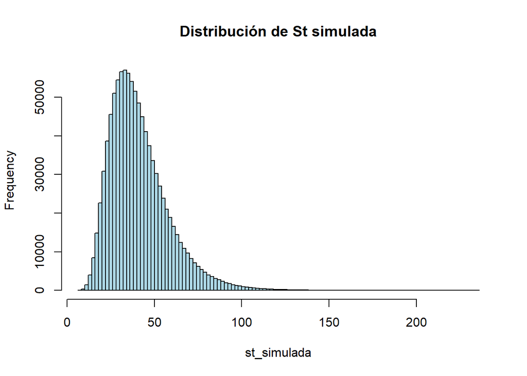

```r
hist(
  st_simulada,
  main = 'Distribución de St simulada',
  n = 100,
  col = 'lightblue'
)
```

```r
jarque.bera.test(st_simulada)
```

```
##
##  Jarque Bera Test
##
## data:  st_simulada
## X-squared = 706723, df = 2, p-value < 2.2e-16
```

**b)** Define:

$$Y_T = \ln S_T.$$

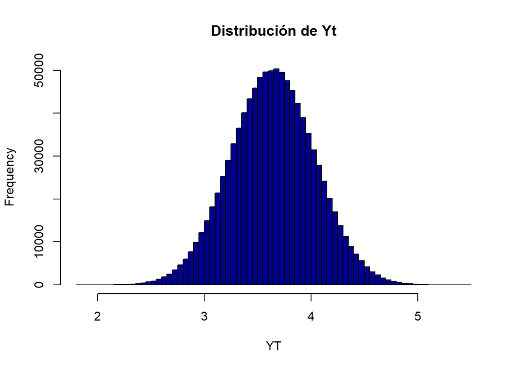

```r
YT <- log(st_simulada)

hist(
  YT,
  main = 'Distribución de Yt',
  n = 100,
  col = 'darkblue'
)
```

Grafica su distribución y aplica Jarque–Bera.

```r
jarque.bera.test(YT)
```

```
##
##  Jarque Bera Test
##
## data:  YT
## X-squared = 1.1788, df = 2, p-value = 0.5547
```

**c)** Define:

$$r_{0,T} = \ln\left( \frac{S_T}{S_0}
\right).$$

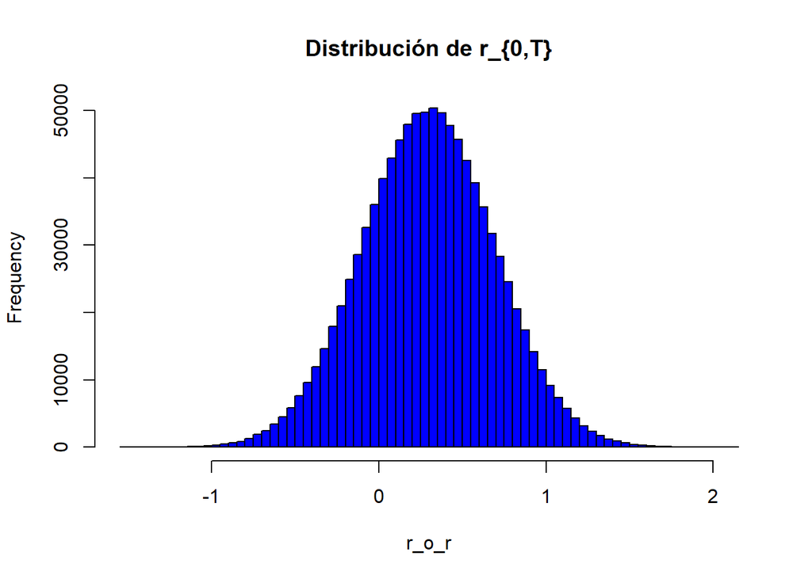

```r
r_o_r <- log(st_simulada / So)

hist(
  r_o_r,
  main = 'Distribución de r_{0,T}',
  n = 100,
  col = 'blue'
)
```

Grafica su distribución y aplica Jarque–Bera.

```r
jarque.bera.test(r_o_r)
```

```
##
##  Jarque Bera Test
##
## data:  r_o_r
## X-squared = 1.1788, df = 2, p-value = 0.5547
```

**d)** ¿Qué variable debería ser Normal bajo GBM?

Deben ser normales $Y_T = \ln S_T$ y $r_{0,T} = \ln(S_T/S_0)$. De la solución exacta,

$$r_{0,T} = \ln\frac{S_T}{S_0} = \left(\mu
- \tfrac12\sigma^2\right)T + \sigma W_T, \qquad W_T = \sqrt{T}Z \sim
N(0, T),$$

así que $r_{0,T} \sim N\!\left((\mu - \tfrac12\sigma^2)T,\ \sigma^2T\right)$ y $Y_T = \ln S_0 + r_{0,T} \sim N\!\left(\ln S_0 + (\mu - \tfrac12\sigma^2)T,\ \sigma^2T\right)$. Las dos son funciones lineales de un solo movimiento browniano.

Las dos solo difieren en la constante $\ln S_0$. Sumar una constante no cambia la asimetría ni la curtosis, así que el estadístico de Jarque–Bera es idéntico: $JB = 1.179$ con p-value 0.555. No se rechaza la normalidad, como predice el modelo.

La normalidad de los log-rendimientos es una **implicación del GBM**, no un hecho empírico garantizado por los mercados.

**e)** ¿Qué variable debería ser lognormal?

Debe ser lognormal $S_T$, el precio en nivel. Como $S_T = e^{Y_T}$ con $Y_T$ normal, $S_T$ es por definición lognormal. De ahí se siguen sus propiedades:

- **Positividad:** $P(S_T > 0) = 1$.
- **Asimetría a la derecha:** en la simulación, la asimetría de $S_T$ es 1.31.
- **Orden de los centros:** moda < mediana < media, porque $S_0e^{(\mu - 3\sigma^2/2)T} < S_0e^{(\mu - \sigma^2/2)T} < S_0e^{\mu T}$.

Por eso Jarque–Bera rechaza con fuerza la normalidad de $S_T$ ($JB = 706,723$). Ese rechazo **confirma** el modelo, no lo contradice: el GBM genera log-rendimientos normales y precios lognormales.

**f)** Compara los resultados simulados con los resultados empíricos del Problema 2. ¿Qué diferencia observas entre “lo que el modelo genera” y “lo que los datos reales muestran”?

| Log-rendimientos | Jarque–Bera | p-value | Conclusión |
| --- | --- | --- | --- |
| Simulados (GBM) | 1.18 | 0.555 | Normales |
| Reales (BBVA) | 5,309.6 | < 0.001 | No normales |

**Lo que el modelo genera** es exactamente lo que se le impuso: incrementos brownianos independientes, $\mu$ y $\sigma$ constantes y trayectorias continuas. Por construcción, sus log-rendimientos son normales, simétricos, sin colas pesadas y sin agrupamiento de volatilidad.

**Lo que muestran los datos** son los hechos estilizados:

- colas pesadas, con curtosis 11.6 contra 3;
- asimetría negativa (-0.7);
- volatilidad que cambia en el tiempo y se agrupa;
- saltos como el de marzo de 2020, incompatibles con trayectorias continuas.

La diferencia no está en la simulación: está en los **supuestos**. Los resultados formales valen lo que valen los supuestos que los generan. Bajo GBM, los log-rendimientos diarios también deberían ser normales, así que la comparación es válida aunque la simulación sea a un año.

La consecuencia para el análisis de riesgo es que el GBM calibrado con la volatilidad histórica reproduce bien el centro de la distribución, pero **subestima la probabilidad de movimientos extremos**, sobre todo de caídas. Es un modelo de referencia, no una descripción completa del mercado.

## Problema 8. Euler–Maruyama vs. solución exacta

Simula una trayectoria de un año usando la misma secuencia de shocks $Z_t$ para ambos métodos.

**a)** Simula Euler–Maruyama:

$$S_{t+\Delta t} \approx S_t + \mu S_t
\Delta t + \sigma S_t \sqrt{\Delta t}\, Z_t.$$

```r
n_dias <- 252; z_simulacion <- rnorm(252); dt <- 1/n_dias
```

```r
S_euler_maruyama <- numeric(n_dias + 1)
S_euler_maruyama[1] <- So

for (i in 1:n_dias) {
  S_euler_maruyama[i+1] <- S_euler_maruyama[i] + S_euler_maruyama[i] * mu_l * dt + sigma_anual_l * S_euler_maruyama[i] * sqrt(dt) * z_simulacion[i]
}
```

**b)** Simula la transición exacta:

$$S_{t+\Delta t} = S_t e^{ \left( \mu -
\tfrac{1}{2}\sigma^2 \right) \Delta t + \sigma \sqrt{\Delta t}\, Z_t
}.$$

```r
S_exacta <- numeric(n_dias + 1)
S_exacta[1] <- So

for (i in 1:n_dias) {
  S_exacta[i+1] <- S_exacta[i] * exp((mu_l - 0.5 * sigma_anual_l^2) * dt + sigma_anual_l * sqrt(dt) * z_simulacion[i])
}
```

**c)** Grafica ambas trayectorias en la misma figura.

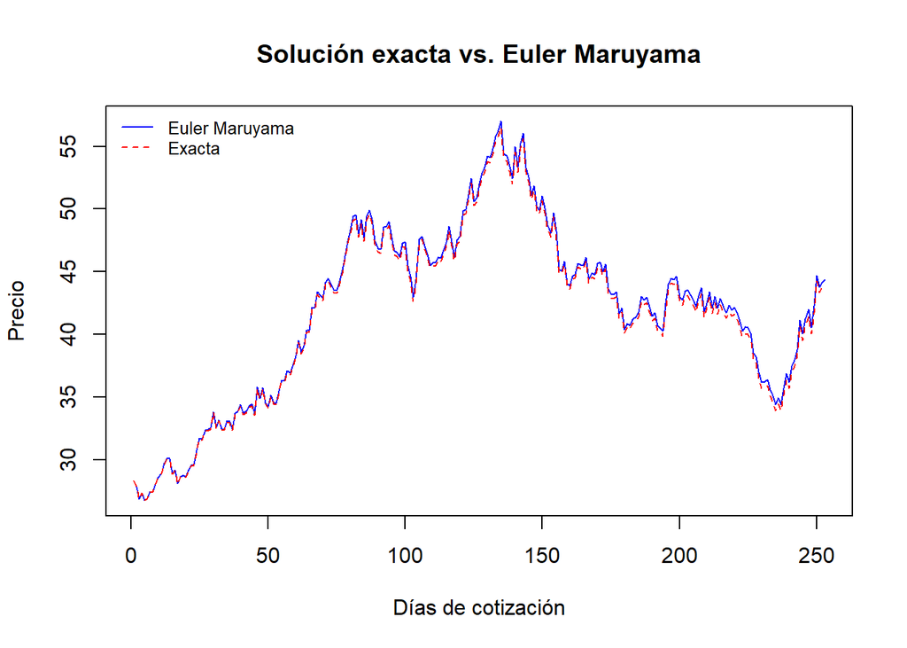

```r
matplot(
  cbind(S_euler_maruyama, S_exacta),
  type = 'l',
  lty  = c(1, 2),
  col  = c('blue', 'red'),
  xlab = 'Días de cotización',
  ylab = 'Precio',
  main = 'Solución exacta vs. Euler Maruyama'
)

legend(
  'topleft',
  legend = c('Euler Maruyama', 'Exacta'),
  col = c('blue', 'red'),
  lty = c(1, 2),
  bty = 'n',
  cex = 0.8
)
```

**d)** Calcula el error absoluto al final del horizonte:

$$\left| S_T^{EM} - S_T^{\text{exact}}
\right|.$$

```r
error_absoluto <- abs(
  S_euler_maruyama[n_dias + 1] - S_exacta[n_dias + 1]
)

error_absoluto
```

```
## [1] 0.4923663
```

**e)** Repite el ejercicio usando:

$$\Delta t = \frac{1}{252}, \qquad \Delta
t = \frac{1}{52}, \qquad \Delta t = \frac{1}{12}.$$

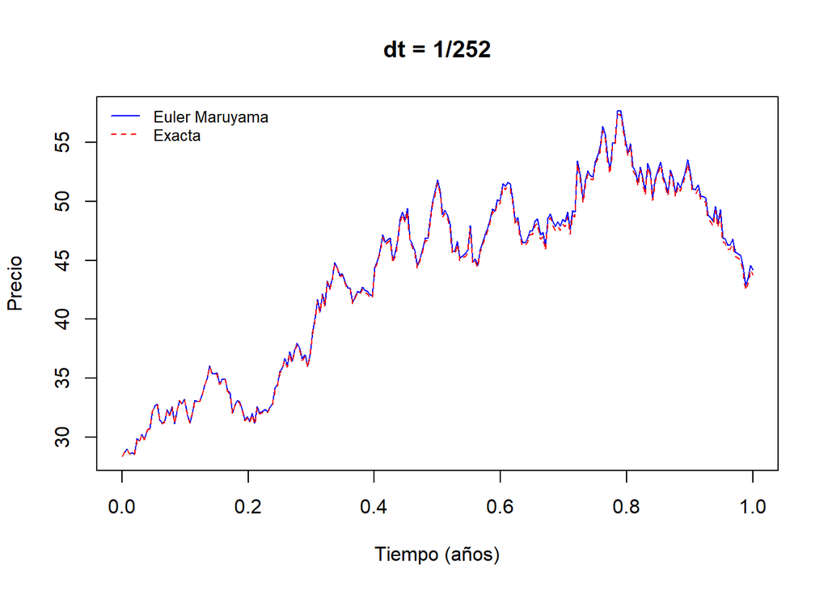

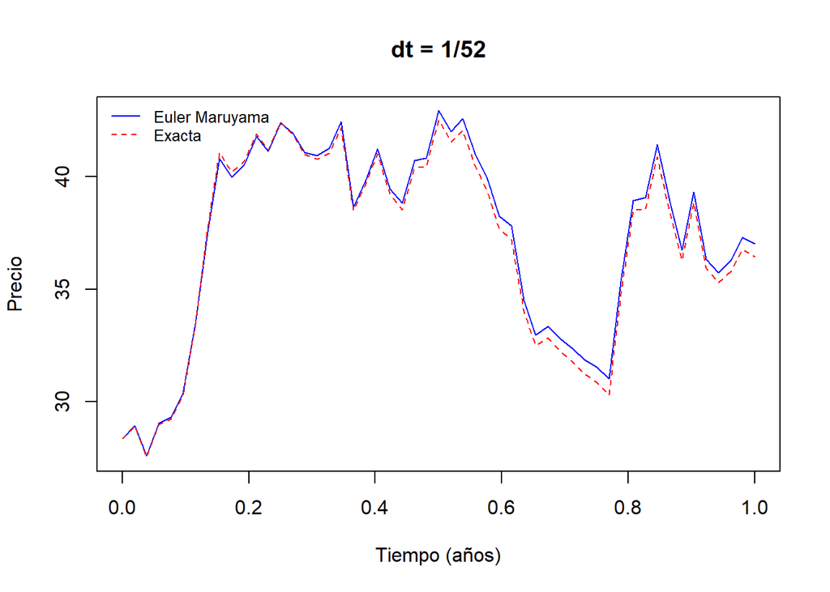

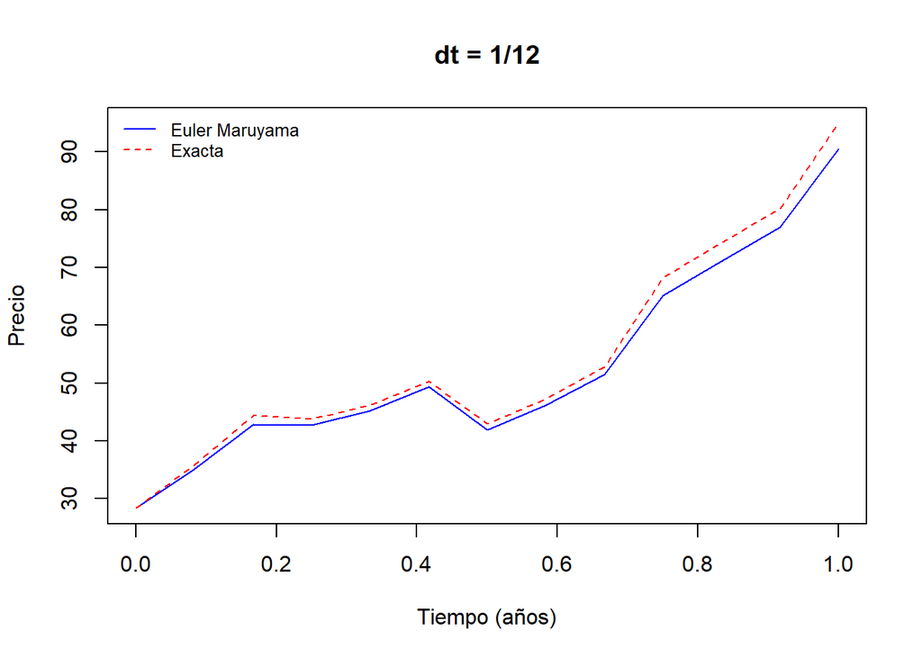

```r
pasos <- c(252, 52, 12)
resultados <- data.frame(
  n_pasos = pasos,
  dt = 1 / pasos,
  error_absoluto = NA_real_
)

par(mfrow = c(1, 1))

for (j in seq_along(pasos)) {
  n <- pasos[j]
  dt <- 1 / n
  z <- rnorm(n)  # Mismos shocks para ambos métodos

  S_em <- numeric(n + 1)
  S_ex <- numeric(n + 1)

  S_em[1] <- So
  S_ex[1] <- So

  for (i in seq_len(n)) {
    S_em[i + 1] <- S_em[i] +
      mu_l * S_em[i] * dt +
      sigma_anual_l * S_em[i] * sqrt(dt) * z[i]

    S_ex[i + 1] <- S_ex[i] * exp(
      (mu_l - 0.5 * sigma_anual_l^2) * dt +
        sigma_anual_l * sqrt(dt) * z[i]
    )
  }

  resultados$error_absoluto[j] <- abs(S_em[n + 1] - S_ex[n + 1])

  matplot(
    seq(0, 1, length.out = n + 1),
    cbind(S_em, S_ex),
    type = 'l',
    lty = c(1, 2),
    col = c('blue', 'red'),
    xlab = 'Tiempo (años)',
    ylab = 'Precio',
    main = paste0('dt = 1/', n)
  )

  legend(
    'topleft',
    legend = c('Euler Maruyama', 'Exacta'),
    col = c('blue', 'red'),
    lty = c(1, 2),
    bty = 'n',
    cex = 0.8
  )
}
```

```r
knitr::kable(resultados)
```

| n_pasos | dt | error_absoluto |
| --- | --- | --- |
| 252 | 0.0039683 | 0.4056973 |
| 52 | 0.0192308 | 0.5744909 |
| 12 | 0.0833333 | 4.4320179 |

**f)** ¿Qué relación observas entre el tamaño del paso y el error?

```r
n_trayectorias <- 5000
pasos <- c(252, 52, 12)

error_medio <- sapply(pasos, function(n) {
  dt   <- 1 / n
  S_em <- rep(So, n_trayectorias)
  S_ex <- rep(So, n_trayectorias)

  for (i in seq_len(n)) {
    z_i  <- rnorm(n_trayectorias)          # mismo shock para ambos métodos
    S_em <- S_em + mu_l * S_em * dt + sigma_anual_l * S_em * sqrt(dt) * z_i
    S_ex <- S_ex * exp((mu_l - 0.5 * sigma_anual_l^2) * dt + sigma_anual_l * sqrt(dt) * z_i)
  }

  mean(abs(S_em - S_ex))
})

tabla_8f <- data.frame(
  n_pasos             = pasos,
  dt                  = 1 / pasos,
  error_medio         = error_medio,
  error_entre_raiz_dt = error_medio / sqrt(1 / pasos)
)

knitr::kable(tabla_8f)
```

| n_pasos | dt | error_medio | error_entre_raiz_dt |
| --- | --- | --- | --- |
| 252 | 0.0039683 | 0.2302393 | 3.654936 |
| 52 | 0.0192308 | 0.5012998 | 3.614924 |
| 12 | 0.0833333 | 1.1006401 | 3.812729 |

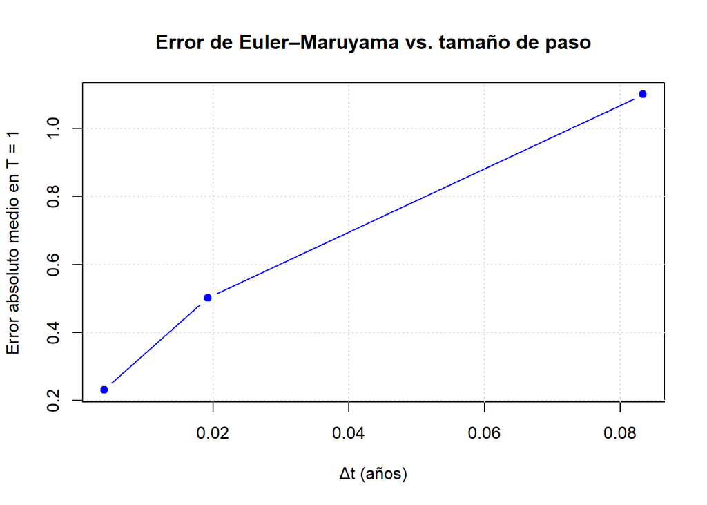

```r
plot(tabla_8f$dt, tabla_8f$error_medio, type = 'b', pch = 19, col = 'blue',
     xlab = 'Δt (años)', ylab = 'Error absoluto medio en T = 1',
     main = 'Error de Euler–Maruyama vs. tamaño de paso')
grid()
```

**A mayor paso, mayor error.** Con una sola trayectoria (inciso e), los errores fueron 0.406, 0.574, 4.432 para $\Delta t$ = 1/252, 1/52 y 1/12. Una sola realización depende mucho de los choques que salieron, por eso se promedió sobre 5,000 trayectorias. El error medio fue 0.23, 0.501, 1.101, y el cociente $\text{error}/\sqrt{\Delta t}$ se mantiene casi constante (entre 3.61 y 3.81):

$$\text{error} \propto \sqrt{\Delta
t}.$$

Reducir el paso a la cuarta parte reduce el error aproximadamente a la mitad.

**Por qué ocurre.** Con los mismos choques, un paso exacto multiplica por $e^{(\mu - \sigma^2/2)\Delta t + \sigma\sqrt{\Delta t}Z}$ y uno de Euler–Maruyama por $1 + \mu\Delta t + \sigma\sqrt{\Delta t}Z$. Al expandir la exponencial:

$$e^{(\mu - \sigma^2/2)\Delta t +
\sigma\sqrt{\Delta t}Z} = 1 + \mu\Delta t + \sigma\sqrt{\Delta t}Z +
\tfrac12\sigma^2\Delta t\,(Z^2 - 1) + O(\Delta t^{3/2}).$$

En cada paso, Euler–Maruyama omite el término $\tfrac12\sigma^2\Delta t(Z^2 - 1)$. Es precisamente el término de Itô que aparece porque $(dW_t)^2 = dt$: el término de segundo orden que el cálculo ordinario desprecia pero el estocástico no. Cada error es de orden $\Delta t$ con media cero. Al acumular $1/\Delta t$ pasos, se suman como variables aleatorias y su desviación estándar es de orden $\sqrt{1/\Delta t}\cdot\Delta t = \sqrt{\Delta t}$, que es justo lo que muestra la tabla.

Cuando $\Delta t \to 0$, Euler–Maruyama converge a la solución exacta, pero lentamente. La transición exacta no tiene error de discretización: es exacta con cualquier tamaño de paso.

**g)** Explica por qué la solución exacta preserva positividad y Euler–Maruyama no necesariamente.

**Solución exacta.** Cada paso multiplica el precio por una exponencial:

$$S_{t+\Delta t} = S_t \cdot
\exp\!\left[\left(\mu - \tfrac12\sigma^2\right)\Delta t +
\sigma\sqrt{\Delta t}\,Z_t\right].$$

La exponencial es estrictamente positiva para cualquier valor de $Z_t$, por extremo que sea. Si $S_0 > 0$, todos los precios de la trayectoria son positivos, sin importar $\Delta t$. Es la misma razón por la que $S_T$ es lognormal: el modelo describe cambios proporcionales y trabaja en escala logarítmica.

**Euler–Maruyama.** Cada paso multiplica el precio por un factor lineal en $Z_t$:

$$S_{t+\Delta t} = S_t\left(1 + \mu\Delta
t + \sigma\sqrt{\Delta t}\,Z_t\right).$$

Ese factor es negativo cuando $Z_t < -\dfrac{1 + \mu\Delta t}{\sigma\sqrt{\Delta t}}$. Como la normal tiene soporte en toda la recta real, esa probabilidad siempre es positiva. Localmente, Euler–Maruyama se comporta como un movimiento browniano aritmético, que puede asignar probabilidad a valores negativos.

Qué tan grave es depende de $\sigma$ y $\Delta t$:

- Para BBVA con pasos mensuales, la probabilidad por paso es $\approx 9.9\times 10^{-20}$: despreciable en la práctica.
- Con los parámetros del Problema 9 ($\sigma = 0.65$) y un solo paso anual, sube a $\Phi(-1.15/0.65) \approx 0.038$: casi 4 % de probabilidad de un precio negativo.

Euler–Maruyama es una aproximación numérica que puede producir precios negativos con pasos gruesos o choques extremos. La transición exacta es estrictamente positiva siempre que $S_t > 0$.

## Problema 9. Horizonte temporal y probabilidad

Considere ahora un activo hipotético con

$$S_0 = 15, \qquad \mu = 0.15, \qquad
\sigma = 0.65.$$

Queremos estudiar:

$$P(S_T > 18).$$

```r
So <- 15; mu <- 0.15; sigma <- 0.65
```

**a)** Calcula la probabilidad teórica para:

$$T = \frac{1}{12}, \qquad T = 0.5, \qquad
T = 1.$$

```r
Ts <- c(
  '1 mes' = 1/12,
  '6 meses' = 0.5,
  '1 año' = 1
)
```

```r
z <- (log(18 / So) - (mu - 0.5 * sigma^2) * Ts) / (sigma * sqrt(Ts))

probs <- pnorm(
  z,
  mean = 0,
  sd = 1,
  lower.tail = FALSE
)

tabla_9s <- data.frame(
  Horizonte = names(Ts),
  Probabilidad = unname(probs)
)

knitr::kable(tabla_9s)
```

| Horizonte | Probabilidad |
| --- | --- |
| 1 mes | 0.1589302 |
| 6 meses | 0.3215709 |
| 1 año | 0.3539323 |

**b)** Verifica cada resultado mediante Monte Carlo.

```r
prob_mc <- sapply(Ts, function(t) {
  Z <- rnorm(1000000)

  ST <- So * exp(
    (mu - 0.5 * sigma^2) * t + sigma * sqrt(t) * Z
  )

  mean(ST > 18)
})

tabla_9b <- data.frame(
  Horizonte = names(Ts),
  Teorica = unname(probs),
  Monte_Carlo = unname(prob_mc),
  Error_absoluto = unname(abs(prob_mc - probs))
)

knitr::kable(tabla_9b)
```

| Horizonte | Teorica | Monte_Carlo | Error_absoluto |
| --- | --- | --- | --- |
| 1 mes | 0.1589302 | 0.158874 | 0.0000562 |
| 6 meses | 0.3215709 | 0.320847 | 0.0007239 |
| 1 año | 0.3539323 | 0.353087 | 0.0008453 |

**c)** Generaliza tu código para evaluar

$$P(S_T > 18)$$

```r
meses <- 1:240
Ts <- meses / 12

z <- (log(18 / So) - (mu - 0.5 * sigma^2) * Ts) /
  (sigma * sqrt(Ts))

probabilidades <- pnorm(z,
                        mean = 0,
                        sd = 1,
                        lower.tail = FALSE
                        )

tabla_9c <- data.frame(
  Mes = meses,
  Años = Ts,
  Probabilidad = probabilidades
)

knitr::kable(tabla_9c[tabla_9c$Mes %% 12 == 0, ], row.names = FALSE)
```

| Mes | Años | Probabilidad |
| --- | --- | --- |
| 12 | 1 | 0.3539323 |
| 24 | 2 | 0.3700949 |
| 36 | 3 | 0.3725314 |
| 48 | 4 | 0.3711879 |
| 60 | 5 | 0.3683798 |
| 72 | 6 | 0.3649236 |
| 84 | 7 | 0.3611719 |
| 96 | 8 | 0.3572964 |
| 108 | 9 | 0.3533876 |
| 120 | 10 | 0.3494951 |
| 132 | 11 | 0.3456467 |
| 144 | 12 | 0.3418583 |
| 156 | 13 | 0.3381384 |
| 168 | 14 | 0.3344913 |
| 180 | 15 | 0.3309188 |
| 192 | 16 | 0.3274207 |
| 204 | 17 | 0.3239960 |
| 216 | 18 | 0.3206434 |
| 228 | 19 | 0.3173606 |
| 240 | 20 | 0.3141456 |

para valores mensuales de $T$ desde 1 mes hasta 20 años.

**d)** Construye una gráfica con:

- $T$ en el eje horizontal y
- $P(S_T > 18)$ en el eje vertical.

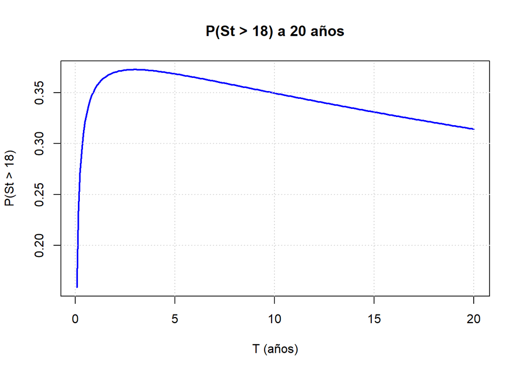

```r
plot(
  Ts, probabilidades,
  type = 'l',
  col = 'blue',
  lwd = 2,
  xlab = 'T (años)',
  ylab = 'P(St > 18)',
  main = 'P(St > 18) a 20 años'
)

grid()
```

**e)** Describe la forma de la gráfica.

La curva tiene forma de **joroba asimétrica**:

- **Sube rápido en horizontes cortos.** Parte de 0.159 a un mes. Cuando $T \to 0$ tiende a cero, porque $S_0 = 15 < 18$ y en muy poco tiempo el precio no alcanza a moverse lo suficiente.
- **Llega a un máximo** de 0.3725 alrededor de $T \approx 3$ años.
- **Después baja lentamente**: 0.349 a 10 años y 0.314 a 20 años. Sigue bajando hacia cero, aunque muy despacio.

El tramo de subida es corto y empinado, y el de bajada largo y suave. En ningún horizonte la probabilidad de terminar arriba de 18 supera el 38 %.

**f)** ¿La probabilidad tiene que aumentar monótonamente con el tiempo? Justifica a partir de la fórmula del GBM y de los parámetros del problema.

**No.** Bajo GBM,

$$P(S_T > K) = 1 - \Phi\big(d(T)\big),
\qquad d(T) = \frac{\ln(K/S_0) - (\mu -
\tfrac12\sigma^2)T}{\sigma\sqrt{T}}.$$

La probabilidad crece cuando $d(T)$ baja y decrece cuando $d(T)$ sube. Con $a = \ln(18/15) = 0.1823$ y $b = \mu - \tfrac12\sigma^2$:

$$d(T) =
\underbrace{\frac{a}{\sigma\sqrt{T}}}_{\text{efecto dispersión}} \; - \;
\underbrace{\frac{b\sqrt{T}}{\sigma}}_{\text{efecto
drift}}.$$

La clave es el signo de $b$. Con estos parámetros,

$$b = \mu - \tfrac12\sigma^2 = 0.15 -
\tfrac12(0.65)^2 = -0.06125 < 0.$$

Aunque $\mu > 0$, la volatilidad es tan alta que la corrección de Itô vuelve **negativo** el drift del log-precio. Hay dos fuerzas opuestas:

1. **Efecto dispersión (domina al inicio).** $a/(\sigma\sqrt{T})$ decrece con $T$. La varianza $\sigma^2T$ crece y reparte más probabilidad hacia la cola derecha, lo que acerca al nivel 18.
2. **Efecto drift (domina después).** Como $b < 0$, el término $-b\sqrt{T}/\sigma = |b|\sqrt{T}/\sigma$ crece sin límite. La mediana, $S_0e^{bT}$, cae con el tiempo: a 20 años es 4.41, muy por debajo de 18.

Al derivar $d(T)$ e igualar a cero se obtiene el punto de equilibrio:

$$T^* = \frac{a}{|b|} = 2.977 \text{
años}, \qquad P_{\max} = 1 -
\Phi\!\left(\frac{2\sqrt{a|b|}}{\sigma}\right) = 0.3725,$$

que coincide con el máximo de la gráfica. Para $T > T^*$, $d(T) \to \infty$ y $P(S_T > 18) \to 0$.

La paradoja es que $E[S_T] = 15e^{0.15T}$ crece exponencialmente (301.3 a 20 años), mientras la probabilidad de superar 18 tiende a cero. La media está dominada por escenarios muy raros y muy grandes de la cola derecha de la lognormal, mientras que la trayectoria típica, descrita por la mediana, cae.

La monotonía depende del signo de $\mu - \tfrac12\sigma^2$: si fuera positivo (por ejemplo, con $\sigma$ menor), ambos efectos empujarían en la misma dirección y la probabilidad crecería monótonamente hacia 1.

## Problema 10. Reflexión final

Responde de manera argumentada.

**a)** ¿Qué diferencia existe entre estimar un modelo y validar un modelo?

**Estimar** es asignar valores a los parámetros *suponiendo que el modelo es correcto*. En el Problema 1 supusimos GBM y, a partir de $E[r_{\Delta t}] = (\mu - \tfrac12\sigma^2)\Delta t$ y $Var(r_{\Delta t}) = \sigma^2\Delta t$, obtuvimos $\hat\mu = 0.375$ y $\hat\sigma = 0.396$. La estimación siempre produce un número, aunque el modelo esté equivocado.

**Validar** es verificar si las *implicaciones* del modelo son compatibles con los datos. El GBM implica log-rendimientos normales, independientes y con volatilidad constante. Lo contrastamos con Jarque–Bera (Problema 2), con los hechos estilizados (2h) y comparando lo que el modelo genera contra lo que muestran los datos (7f). En BBVA, la validación falla en la normalidad y en la volatilidad constante.

En resumen, estimar responde “¿qué valores toman $\mu$ y $\sigma$ si el modelo es cierto?” y validar responde “¿es razonable creer que el modelo es cierto?”. Un parámetro bien estimado de un modelo inválido sigue dando conclusiones equivocadas.

**c)** ¿Qué supuestos parecen más alejados de los datos reales?

**d)** ¿Qué aprendiste al comparar la aproximación local $dS$ con la solución exacta?

- **El cálculo ordinario no alcanza.** En cálculo ordinario, $\int dS/S = \ln S$. Con un proceso estocástico, el término $(dW_t)^2 = dt$ sobrevive y aparece la corrección $-\tfrac12\sigma^2$. Ignorarla es exactamente el error de la aproximación local.
- **Media y mediana son cosas distintas.** $\mu$ gobierna la media, $S_0e^{\mu T}$, mientras que $\mu - \tfrac12\sigma^2$ gobierna la mediana y la trayectoria típica. El Problema 9 lo muestra de forma extrema: la media crece mientras la probabilidad de subir tiende a cero.
- **La aproximación local solo funciona en intervalos cortos.** A 5 días las probabilidades difieren en 0.011, y a un año en 0.055. La brecha en los valores $z$ es $\sigma\sqrt{T}/2$.
- **Discretizar es aproximar.** Euler–Maruyama repite la aproximación local paso a paso: converge a la solución exacta cuando $\Delta t \to 0$, con error proporcional a $\sqrt{\Delta t}$, y puede producir precios negativos. La transición exacta no tiene error de discretización.
- **Normal frente a lognormal.** La aproximación local trata el cambio de precio como normal y simétrico; la exacta produce precios lognormales, positivos y sesgados a la derecha. Con horizontes largos, la diferencia es fundamental.

**e)** Explica por qué un modelo puede ser útil aun cuando sus supuestos no describan perfectamente la realidad.

Un modelo simplifica la realidad a propósito, y su valor depende de qué gana y qué pierde con cada simplificación. El GBM es útil como **modelo de referencia** porque:

- **Es formal e interpretable.** Cada parámetro tiene un significado claro: $\mu$ es el rendimiento esperado relativo y $\sigma$ la incertidumbre.
- **Es manejable.** Tiene solución cerrada, distribución conocida y fórmulas explícitas para probabilidades e intervalos, y permite simular exactamente.
- **Aísla mecanismos.** Deja ver con claridad efectos que existen en modelos más complejos, como la corrección de Itô, la diferencia entre media y mediana, el crecimiento de la incertidumbre con $\sqrt{T}$ y la asimetría de los precios.
- **Sirve de base.** Los modelos más realistas (volatilidad estocástica, saltos, colas pesadas) se construyen modificando los supuestos del GBM. Saber dónde falla indica qué hay que agregar.
- **Permite comparar.** Da un lenguaje común para comparar activos y horizontes, y sirve como primera aproximación para el centro de la distribución.

La utilidad exige conocer los límites. En este caso, el GBM subestima el riesgo de eventos extremos, así que sus probabilidades de cola deben complementarse con medidas empíricas o pruebas de estrés. Un modelo simple que se sabe dónde falla es más útil que uno complejo que nadie entiende.

**f)** Resume la práctica completando:

$$\text{datos} \rightarrow
\text{parámetros} \rightarrow \text{modelo} \rightarrow
\text{simulación} \rightarrow \text{evaluación}$$

con una frase para cada etapa.

- **Datos:** descargamos 6.7 años de precios ajustados de BBVA y los transformamos en log-rendimientos, que no dependen de la escala y se suman en el tiempo.
- **Parámetros:** con la media y la desviación estándar de los log-rendimientos, más la corrección de Itô, estimamos $\hat\mu \approx 0.375$ y $\hat\sigma \approx 0.396$ anuales.
- **Modelo:** bajo GBM, la solución exacta implica log-rendimientos normales y precios lognormales, con fórmulas cerradas para la media, la varianza, la mediana, los intervalos y las probabilidades.
- **Simulación:** con un millón de escenarios verificamos las fórmulas, comparamos la aproximación local con la exacta y medimos cómo el error de Euler–Maruyama depende del tamaño de paso.
- **Evaluación:** la simulación reproduce la teoría, pero los datos reales (colas pesadas, asimetría y volatilidad cambiante) rechazan la normalidad. El GBM es un modelo de referencia útil, no una descripción completa del riesgo de BBVA.

### Idea central

La simulación no sustituye a la teoría y la teoría no sustituye a los datos: las tres piezas —datos, modelo y simulación— deben utilizarse conjuntamente para analizar el riesgo financiero.